# Precipitación Madrid

#### Cantidad

```r
model_cantidad = keras_model_sequential()
model_cantidad %>%
  layer_dense(units = 200,input_shape = dim(meteo$x_train)[2],activation = "sigmoid",kernel_regularizer = regularizer_l1(0.0001)) %>%
  layer_dropout(rate = 0.5) %>%
  layer_dense(units = 100,activation = "sigmoid") %>%
  layer_dropout(rate = 0.5) %>%
  layer_dense(units = 50,activation = "sigmoid") %>%
  layer_dropout(rate = 0.5) %>%
  layer_dense(units = 1)
str(model_cantidad)
```

```
Model
Model: "sequential_25"
________________________________________________________________________________________________________________
Layer (type)                                      Output Shape                                 Param #
================================================================================================================
dense_84 (Dense)                                  (None, 200)                                  64200
________________________________________________________________________________________________________________
dropout_59 (Dropout)                              (None, 200)                                  0
________________________________________________________________________________________________________________
dense_85 (Dense)                                  (None, 100)                                  20100
________________________________________________________________________________________________________________
dropout_60 (Dropout)                              (None, 100)                                  0
________________________________________________________________________________________________________________
dense_86 (Dense)                                  (None, 50)                                   5050
________________________________________________________________________________________________________________
dropout_61 (Dropout)                              (None, 50)                                   0
________________________________________________________________________________________________________________
dense_87 (Dense)                                  (None, 1)                                    51
================================================================================================================
Total params: 89,401
Trainable params: 89,401
Non-trainable params: 0
________________________________________________________________________________________________________________
```

Compilación de Cantidad: - Opimizador Adam, de manera que se puede acercar al mínimo de más rápido juntando momentum y división de ventana móvil. - Función de coste como Error Medio Cuadrático (MSE), ya que estamos prediciendo la precipitación. - No se usan métricas adicionales.

```r
model_cantidad %>% compile(optimizer = optimizer_adam(lr = 0.001),loss = "mse")
```

Entrenamiento de Cantidad: - 500 épocas para entrenar. - Tamaño de batch de 100. - Callback de detención temprana para evitar que el modelo continúe aprendiendo en sobreajuste. - Se usaron los datos de validación extraídos del dataset original.

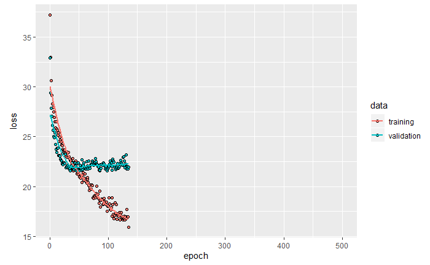

```r
history_cantidad = model_cantidad %>% fit(meteo$x_train,
                                          meteo$y_train,
                                          epochs = 500,
                                          batch_size = 100,
                                          callbacks = list(callback_early_stopping(patience = 50)),
                                          validation_data = list(meteo$x_val,meteo$y_val),
                                          verbose = 0)
plot(history_cantidad)
```

Evaluación del modelo con los datos de Test:

```r
evaluation_cantidad = model_cantidad %>% evaluate(meteo$x_test,meteo$y_test,verbose = 0)
evaluation_cantidad
```

```
    loss
30.51476
```

Se observa un MSE bastante alto para los datos de Test, llegando incluso a ser más alto que el mejor MSE obtenido por los datos de Validación.

#### Ocurrencia x Cantidad

Se combinan los datos de ocurrencia y de cantidad para observar si se logra una mejora en los resultados de Cantidad.

```r
ocurrencia = predict_classes(model_ocurrencia,meteo$x_test)
cantidad = predict(model_cantidad,meteo$x_test)
cantidadOcurrencia = cantidad*ocurrencia
```

Se utiliza como métrica de comparación la Raíz del Error Cuadrático Medio (RMSE).

```r
RMSE(cantidadOcurrencia,meteo$y_test)
```

```
[1] 5.510138
```

```r
RMSE(cantidad,meteo$y_test)
```

```
[1] 5.467873
```

Se observa que no hay una gran diferencia entre ambas soluciones y que incluso, se obtiene un menor RMSE sin tener en cuenta la ocurrencia.

#### Guardar Modelos

Guardar modelos para su posterior uso.

```r
model_ocurrencia %>% save_model_hdf5("model_ocurrencia.h5")
model_cantidad %>% save_model_hdf5("model_cantidad.h5")
```